# Using TI Resource Explorer & the Radar Toolbox

TI Resource Explorer can be accessed via Code Composer Studio or a web browser. It may appear and behave differently depending on the method. Where applicable, directions have been provided for both methods.

# Get Familiar with TI Resource Explorer

To get familiar with the layout and mechanics of TI Resource Explorer use the **Take a Tour** function.

## From Code Composer Studio (CCS)

1. Open CCS and TI Resource Explorer.
2. In the upper right corner, click the eye icon

## Via Web Browser

1. Navigate to the Radar Toolbox in TI Resource Explorer
2. In the upper right corner click the menu icon and then select Take a Tour

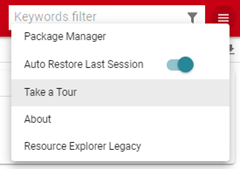

# Installing the Radar Toolbox

TI Resource Explorer and the Radar Toolbox can be accessed via two methods, either via Code Composer Studio or a web browser. If downloading and installing packages, the recommended method is via Code Composer Studio.

## From Code Composer Studio (CCS)

1. Open CCS
2. In the top toolbar, navigate to **View → Resource Explorer**

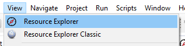

## Via Web Browser

1. Navigate to the Radar Toolbox in [TI Resource Explorer](https://dev.ti.com/tirex/)
2. To download the toolbox either:
   - Click the download button in the upper right corner  
     OR
   - Hover over the toolbox name in the directory tree, click the breadcrumbs, and then select download.

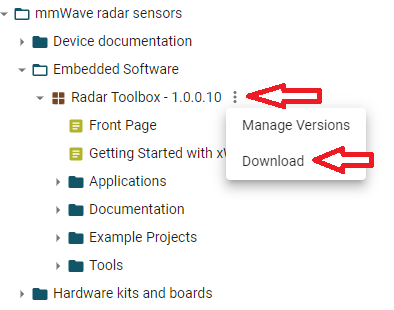

3. Navigate to the .zip file. Right click and then select **Extract All../…**. Do NOT use the default path. The path must be `C:\ti`.

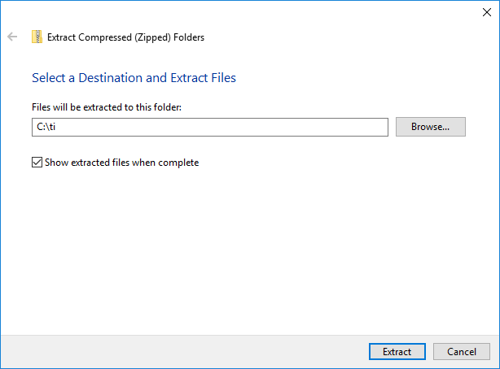

4. Verify installation by navigating to and checking for `C:\ti\radar_toolbox_<VER>`
5. Since the package was downloaded outside of CCS, to be able to easily import projects into CCS it is necessary to sync the downloaded package with CCS.
- Open CCS and TI Resource Explorer.
- In the upper right corner, open the menu and select **Scan Desktop**. If the toolbox was installed at `C:\ti`, CCS should find the package; otherwise edit the search path in **Preferences**.

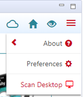

  > NOTE: If a previous toolbox version was downloaded it may be necessary to change the package version in CCS as shown below for the synched package to appear in the directory tree panel.

# Access Previous Toolbox Version

## From Code Composer Studio

1. Open CCS and TI Resource Explorer.
2. In the upper right corner, click **Home**
3. Scroll down and navigate to the Radar Toolbox and use the drop down menu to select the desired version. If the package version has already been installed (and synched to CCS) then selecting it will show a green info icon in the upper right. If not, download button will be enabled.

[figure not shown]

4. The directory tree in the left panel should now show the selected version.

## Via Web Browser

1. Navigate to the Radar Toolbox in [TI Resource Explorer](https://dev.ti.com/tirex/)
2. Hover over the toolbox name in the directory tree, click the breadcrumbs, select either **Change Version** or **Add Version**, and then select the desired version.

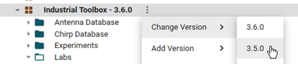

# Import CCS projects from the Radar Toolbox into Code Composer Studio

> 🛑 *Before Continuing!*  
> Before importing any projects, ensure that any dependencies (ie correct version of the mmWave SDK) and the toolbox have been already installed

## Importing via CCS Import Projectspecs

Using this method, manually browse to the location of the toolbox installation and import the desired project.

- Open CCS
- In the top toolbar, navigate to **Project → Import CCS Projects../…**
- With the **Select search-directory** option enabled, click **Browse../…**, navigate to the desired example project folder within `C:\ti\radar_toolbox_<VER>\source\examples\`, and then click **OK**.
- Under **Discovered projects**, select the desired projects then click **Finish**.